# PETALNewExperimentBayesian

- Show All Code
- Hide All Code
- View Source

Author

Affiliation

Imane Lattab

The University of Sydney

Published

October 1, 2026

# Bayesian Analyses on New Data

## Collapsing Motion-Direction

Initially, I will perform the analyses on the data that collapses motion-direction (i.e. everyone’s FLE scores is simply an average of all their trials)

### Data

```r
FLE_data_og <- read.csv(
  "/Users/imanelattab/Desktop/Honours/Data/FlashLagPsychHonours/PartB/FLE_Sep2026_block_data.csv"
)

# Keep only petal motion, preserving the existing block-level summaries
FLE_data_petal <- FLE_data_og |>
  filter(FLE_condition == "petal") |>
  arrange(ID, block)

# Use this name if your subsequent Bayesian code expects FLE_data
FLE_data <- FLE_data_petal
```

Estimate overall mean FLE and participant specific deviations

```r
fle_lmer <- lmer(FLE_dva ~ 1 + (1 | ID), data = FLE_data)

summary(fle_lmer)
```

```
Linear mixed model fit by REML. t-tests use Satterthwaite's method [
lmerModLmerTest]
Formula: FLE_dva ~ 1 + (1 | ID)
   Data: FLE_data

REML criterion at convergence: 2302.2

Scaled residuals:
    Min      1Q  Median      3Q     Max
-9.5782 -0.5299 -0.0005  0.5431  6.2280

Random effects:
 Groups   Name        Variance Std.Dev.
 ID       (Intercept) 1.5014   1.2253
 Residual             0.3853   0.6208
Number of obs: 1042, groups:  ID, 88

Fixed effects:
            Estimate Std. Error      df t value Pr(>|t|)
(Intercept)   2.7991     0.1322 87.0268   21.18   <2e-16 ***
---
Signif. codes:  0 '***' 0.001 '**' 0.01 '*' 0.05 '.' 0.1 ' ' 1
```

```r
mle_p_negative <- pnorm(
  q = 0
  , mean = fixef(fle_lmer)[1]
  , sd = attr(VarCorr(fle_lmer)$ID, "stddev")
)

mle_p_negative
```

```
[1] 0.01117368
```

## Bayesian Hierarchical Model

I am just applying the framework from `flash-lag-effect-extended.html`

### Prior Distributions

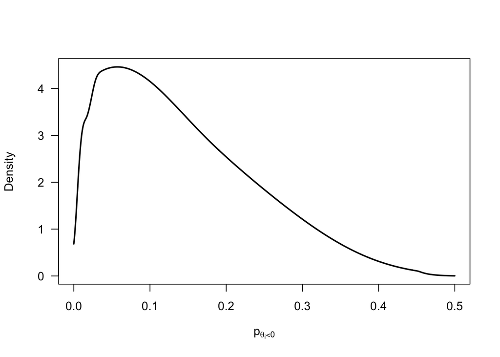

```r
p_negative_prior <- rnorm(1e5, mean = -2/3, sd = 2/3) |>
  pnorm(0) |>
  (\(x) x / 2)()

p_negative_prior |>
  logspline::logspline(lbound = 0, ubound = 0.5) |>
  (
    \(fit) {
      curve(
        logspline::dlogspline(x, fit)
        , from = 0, to = 0.5
        , lwd = 2
        , xlab = expression(p[theta[i] < 0])
        , ylab = "Density"
        , las = 1
        , n = 1001
      )
    }
  )()
```

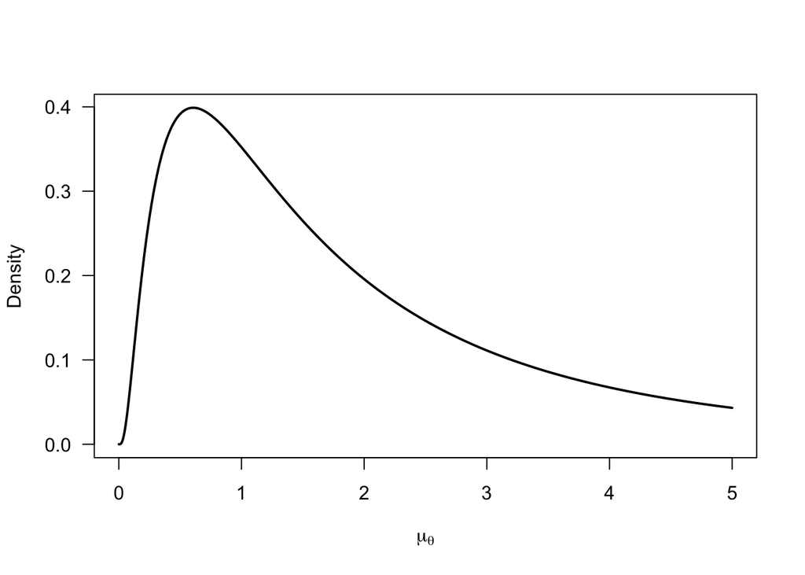

```r
curve(
  dlnorm(x, meanlog = 0.5, sdlog = 1)
  , from = 0, to = 5
  , lwd = 2
  , xlab = expression(mu[theta])
  , ylab = "Density"
  , las = 1
  , n = 1001
)
```

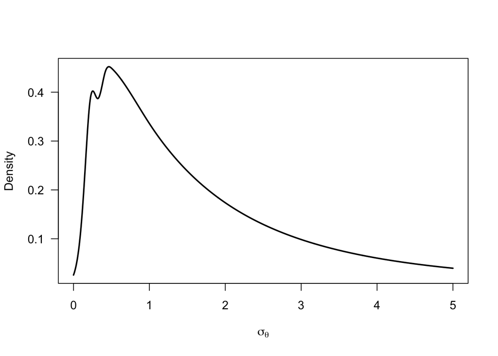

```r
mu_prior <- rlnorm(1e5, meanlog = 0.5, sdlog = 1)
sigma_prior <- -mu_prior / qnorm(p_negative_prior)

sigma_prior |>
  logspline::logspline(lbound = 0) |>
  (
    \(fit) {
      curve(
        logspline::dlogspline(x, fit)
        , from = 0, to = 5
        , lwd = 2
        , xlab = expression(sigma[theta])
        , ylab = "Density"
        , las = 1
        , n = 1001
      )
    }
  )()
```

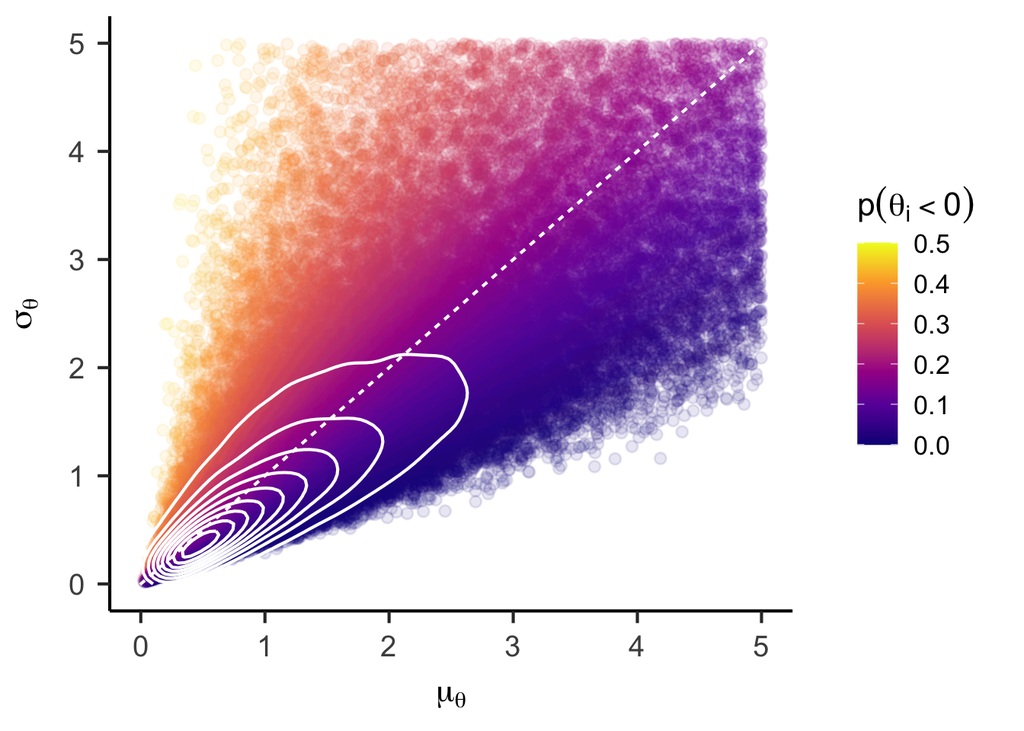

```r
unconstrained_joint_prior <- data.frame(mu = mu_prior, sigma = sigma_prior, p_negative = p_negative_prior) |>
  ggplot() +
    aes(x = mu, y = sigma, color = p_negative) +
    geom_point(alpha = 0.1) +
    stat_density_2d(color = "white", bins = 10) +
    geom_abline(intercept = 0, slope = 1, color = "white", linetype = "22") +
    # annotate("point", x = fixef(fle_lmer)[1], y = attr(VarCorr(fle_lmer)$ID, "stddev"), shape = 21, color = "black", fill = "white", size = 5) +
    labs(
      x = expression(mu[theta])
      , y = expression(sigma[theta])
      , color = expression(p(theta[i] < 0))
    ) +
    scale_color_viridis_c(option = "C", limits = c(0, 0.5)) +
    lims(x = c(0, 5), y = c(0, 5)) +
    papaja::theme_apa(base_size = 16)

unconstrained_joint_prior
```

### Model Estimation

```r
# Read the Stan model
pse_model <- readLines(
  "../PartA/models/pse-unconstrained.stan"
) |>
  paste(collapse = "\n") # model files are from in this github repo https://github.com/alexholcombe/qualitativeIndividDiffsMotnPostnIllusions.git

# Prepare staircase-level data for Stan
FLE_data_model <- FLE_data |>
  filter(
    !is.na(ID),
    !is.na(FLE_dva)
  ) |>
  mutate(
    ID = as.factor(ID),
    subject_id = as.integer(ID)
  ) |>
  arrange(subject_id, block)

# Check number of observations per participant
FLE_data_model |>
  count(ID, name = "n_observations") |>
  count(n_observations)
```

```
  n_observations  n
1              1  1
2              9  1
3             12 86
```

```r
fle_stan_data <- list(
  # Total number of staircase-level FLE estimates
  N = as.integer(nrow(FLE_data_model)),

  # Number of unique participants
  n_subjects = as.integer(n_distinct(FLE_data_model$ID)),

  # Participant index for every observation
  id = as.integer(FLE_data_model$subject_id),

  # Staircase-level FLE estimates in DVA
  y = as.numeric(FLE_data_model$FLE_dva),

  # Prior settings
  pi_mean = -2 / 3,
  pi_sd = 2 / 3,
  mu_theta_mean = 0.5,
  mu_theta_sd = 1
)

stopifnot(
  fle_stan_data$N == length(fle_stan_data$y),
  fle_stan_data$N == length(fle_stan_data$id),
  fle_stan_data$n_subjects == length(unique(fle_stan_data$id)),
  all(is.finite(fle_stan_data$y)),
  min(fle_stan_data$id) == 1L,
  max(fle_stan_data$id) == fle_stan_data$n_subjects
)

str(fle_stan_data)
```

```
List of 8
 $ N            : int 1042
 $ n_subjects   : int 88
 $ id           : int [1:1042] 1 1 1 1 1 1 1 1 1 1 ...
 $ y            : num [1:1042] 4.59 4.53 4.76 4.92 4.16 ...
 $ pi_mean      : num -0.667
 $ pi_sd        : num 0.667
 $ mu_theta_mean: num 0.5
 $ mu_theta_sd  : num 1
```

```r
fle_bayes <- rstan::stan(
  model_code = pse_model,
  data = fle_stan_data,
  iter = 1e5 / 4 + 1000,
  warmup = 1000,
  chains = 4,
  cores = 4,
  seed = 123
)
```

```
Trying to compile a simple C file
```

[output not shown]

```r
# Model diagnostics
str_post_unconstrained <- data.frame(
  summary(fle_bayes)$summary
)

rstan::check_hmc_diagnostics(fle_bayes)
```

```
Divergences:
```

```
0 of 100000 iterations ended with a divergence.
```

```
Tree depth:
```

```
0 of 100000 iterations saturated the maximum tree depth of 10.
```

```
Energy:
```

```
E-BFMI indicated no pathological behavior.
```

```r
data.frame(
  parameter = c("mu_theta", "sigma_theta", "sigma_epsilon", "p_negative_theta")
  , bayes = fle_bayes |>
    summary(pars = c("mu_theta", "sigma_theta", "sigma_epsilon", "p_negative_theta")) |>
    (\(x) x$summary)() |>
    as.data.frame() |>
    dplyr::pull("mean")
  , mle = c(
    fixef(fle_lmer)[1],
    attr(VarCorr(fle_lmer)$ID, "stddev"),
    sigma(fle_lmer),
    mle_p_negative
  )
) |>
  knitr::kable()
```

Table 1: Comparison of Bayesian posterior means and MLE estimates.

| parameter | bayes | mle |
| --- | --- | --- |
| mu_theta | 2.7495429 | 2.7990878 |
| sigma_theta | 1.2811095 | 1.2252993 |
| sigma_epsilon | 0.6208339 | 0.6207556 |
| p_negative_theta | 0.0170364 | 0.0111737 |

```r
fle_bayes |>
  summary(pars = c("mu_theta", "sigma_theta", "sigma_epsilon", "p_negative_theta")) |>
  (\(x) x$summary)() |>
  tidyr::as_tibble(rownames = "parameter") |>
  dplyr::mutate(
    parameter = gsub("mu", "$\\\\mu", parameter) |>
      gsub("sigma", "$\\\\sigma", x = _) |>
      gsub("_(.+)", "_{\\\\\\1}$", x = _) |>
      gsub("^p.+", "$p(\\\\theta_i<0)$", x = _)
  ) |>
  knitr::kable(digits = 3)
```

| parameter | mean | se_mean | sd | 2.5% | 25% | 50% | 75% | 97.5% | n_eff | Rhat |
| --- | --- | --- | --- | --- | --- | --- | --- | --- | --- | --- |
| $\mu_{\theta}$ | 2.750 | 0 | 0.137 | 2.480 | 2.657 | 2.750 | 2.842 | 3.021 | 108629.0 | 1 |
| $\sigma_{\theta}$ | 1.281 | 0 | 0.099 | 1.105 | 1.212 | 1.276 | 1.343 | 1.490 | 134954.0 | 1 |
| $\sigma_{\epsilon}$ | 0.621 | 0 | 0.014 | 0.594 | 0.611 | 0.621 | 0.630 | 0.650 | 125263.2 | 1 |
| $p(\theta_i<0)$ | 0.017 | 0 | 0.008 | 0.005 | 0.011 | 0.016 | 0.021 | 0.037 | 100571.8 | 1 |

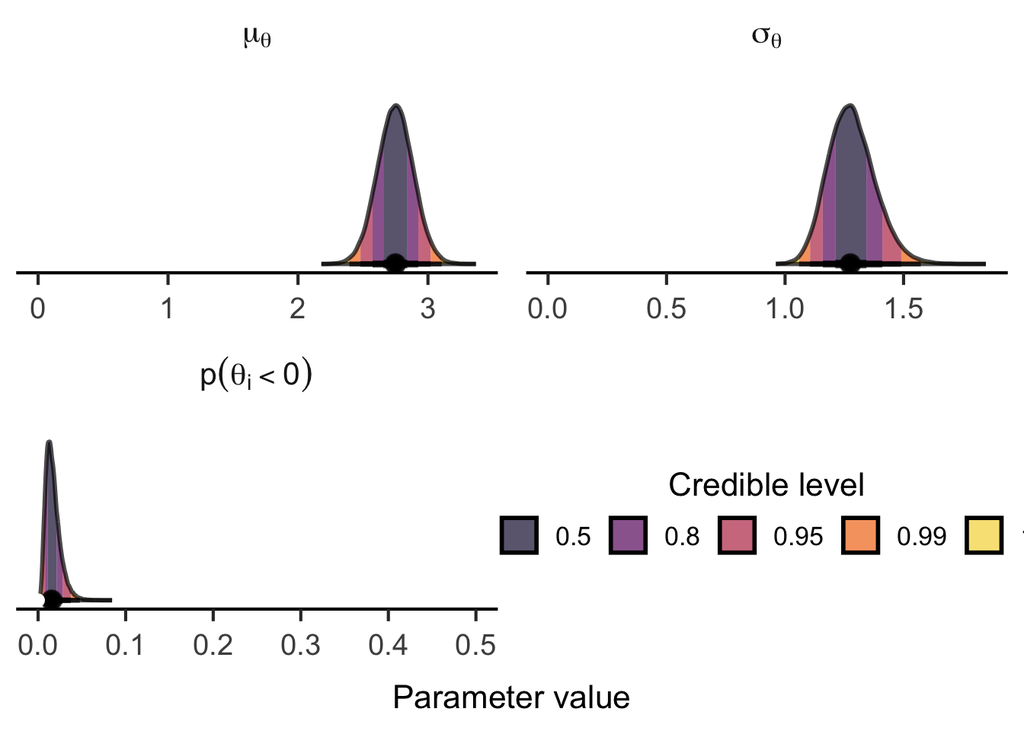

Figure 1: Posterior distributions for the group mean of individual differences $\mu_{\theta}$, the standard deviation of individual differences $\sigma_{\theta}$, and the proportion of participants with a negative flash lag effect $p(\theta_i<0)$.

```r
(tidybayes::gather_draws(
  fle_bayes
  , mu_theta, sigma_theta, p_negative_theta
) |>
  dplyr::mutate(
    .variable = factor(
      .variable
      , levels = c("mu_theta", "sigma_theta", "p_negative_theta")
      , labels = c("mu[theta]", "sigma[theta]", "p(theta[i] < 0)")
    )
  ) |>
  ggplot() +
  aes(x = .value, fill = after_stat(level)) +
  stat_halfeye(fill_type = "segments", normalize = "panels", .width = c(.5, .8, .95, .99, 1), slab_color = "black", alpha = 0.7, fatten_point = 2, interval_size_range = c(1, 2)) +
  annotate("point", x = c(0, 0.5), y = 0, color = "white") +
  scale_fill_viridis_d(option = "B", begin = 0.9, end = 0.1) +
  guides(
    fill = guide_legend(
      title = "Credible level"
      , override.aes = list(color = NA)
      , reverse = TRUE
      , direction = "horizontal"
      , title.position = "top"
      , title.hjust = 0.5
    )
  ) +
  # coord_cartesian(ylim = c(-0.05, NA)) +
  facet_wrap(
    ~ .variable
    , scales = "free"
    , labeller = label_parsed
    , ncol = 2
  ) +
  labs(x = "Parameter value") +
  papaja::theme_apa(base_size = 16) +
  theme(
    axis.line.y = element_blank()
    , axis.ticks.y = element_blank()
    , axis.text.y = element_blank()
    , axis.title.y = element_blank()
    # , legend.title.position = "top"
  )) |>
  lemon::reposition_legend("center", panel = 'panel-2-2')
```

### Estimates of individual effects

```r
theta_i <- tidybayes::gather_draws(
  fle_bayes
  , theta[i]
)

# i as factor sorted by median of posterior distribution
theta_i_ordered <- tidybayes::median_qi(theta_i) |>
  mutate(
    i = factor(
      i
      , labels = unique(i)[order(.value)]
      , levels = unique(i)[order(.value)]
    )
  )

theta_caterpillar <- theta_i |>
  dplyr::mutate(
    # i as factor sorted by median of posterior distribution
    ID = factor(
      i
      , labels = unique(theta_i_ordered$i)[order(theta_i_ordered$.value)]
      , levels = unique(theta_i_ordered$i)[order(theta_i_ordered$.value)]
    )
  ) |>
  dplyr::rename(theta = .value) |>
  ggplot() +
    aes(x = ID, y = theta) +
    geom_hline(yintercept = 0, color = "black", linetype = "22") +
    stat_pointinterval(aes(fill = after_stat(y) < 0, interval_color = after_stat(y) < 0), point_color = "white", .width = c(.95), fatten_point = 2, linewidth = 1, shape = 21) +
    scale_fill_viridis_d(option = "B", begin = 0.9, end = 0.1, aesthetics = c("fill", "interval_color")) +
    guides(interval_color = "none", fill = "none", linewidth = "none") +
    labs(y = expression(theta), x = "Participant ID") +
    coord_cartesian(ylim = c(-5, 7.5)) +
    papaja::theme_apa(base_size = 16) +
    theme(
      # axis.line.x = element_blank()
      # , axis.ticks.x = element_blank()
      , axis.text.x = element_text(size = 8, angle = 90, vjust = 0.5, hjust = 1)
    )
```

```r
posterior_population_distribution <- tidybayes::gather_draws(
  fle_bayes
  , mu_theta, sigma_theta
) |>
  tidyr::nest(data = c(.chain, .iteration, .draw)) |>
  tidyr::pivot_wider(names_from = .variable, values_from = .value) |>
  dplyr::mutate(
    density = purrr::map2(
      mu_theta
      , sigma_theta
      , \(mu, sigma) {
        dnorm(
          x = seq(-5, 7.5, length.out = 101)
          , mean = mu
          , sd = sigma
        )
      }
    )
    , theta = list(seq(-5, 7.5, length.out = 101))
  )

theta_dist <- posterior_population_distribution |>
  tidyr::unnest(cols = c(density, theta)) |>
  ggplot() +
    aes(x = theta, y = density) +
    geom_vline(xintercept = 0, color = "black", linetype = "22") +
    geom_hline(yintercept = 0, color = "black") +
    geom_lineribbon(
      aes(ymin = after_stat(ymin), ymax = after_stat(ymax))
      , stat = "summary"
      , fun.data = "mean_qi"
      , color = "black"
      , fill = "black"
      , alpha = 0.2
    ) +
    # geom_rug(
    #   data = tidybayes::median_qi(theta_i)
    #   , aes(x = .value, y = 0)
    #   , sides = "b"
    #   , color = "black"
    #   , alpha = 0.5
    # ) +
    # geom_point(
    #   data = tidybayes::median_qi(theta_i)
    #   , aes(x = .value, y = 0, fill = .value < 0)
    #   , color = "white"
    #   , shape = 21
    #   , size = 2
    # ) +
    scale_fill_viridis_d(option = "B", begin = 0.9, end = 0.1) +
    guides(fill = "none") +
    labs(x = expression(theta), y = "Density") +
    papaja::theme_apa(base_size = 16)
```

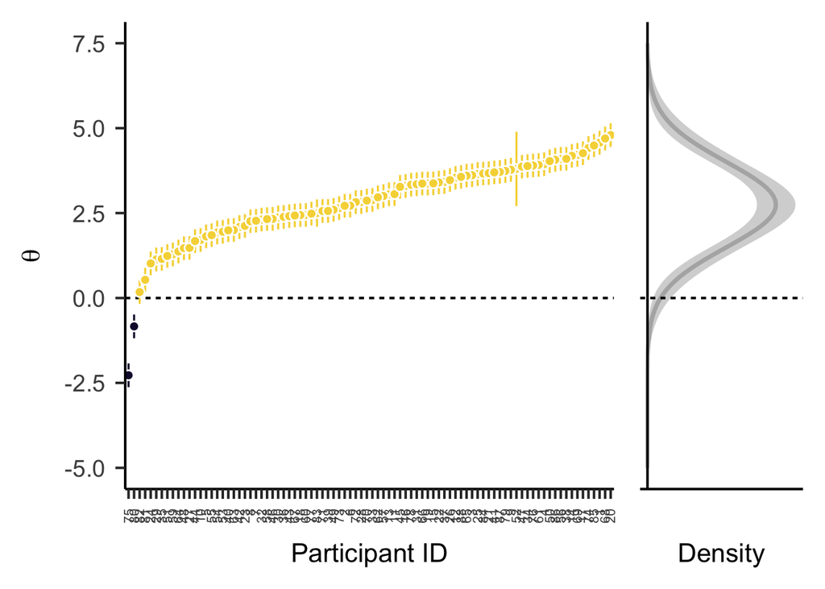

Figure 2: Posterior distribution of individual effects $\theta_i$ for each participant (left) and the posterior distribution of the population distribution of individual effects $\theta_i$ (right). The horizontal dashed line marks the point of no effect, i.e., $\theta_i = 0$.

```r
theta_caterpillar + (theta_dist + coord_flip() + theme(axis.ticks.x = element_blank(), axis.text.x = element_blank())) +
  plot_layout(ncol = 2, widths = c(1, 1/3), guides = "collect", axes = "collect_y")
```

## Bayes factor approximations

Finally, we compute the Bayes factor in favor of the assumption of an unconstrained population distribution ($p(\theta_i<0) > 0$) over the strictly positive population distribution (stochastic dominance). One approach is to approximate this Bayes factor using the Savage-Dickey density ratio for $p(\theta_i<0) = 0$.

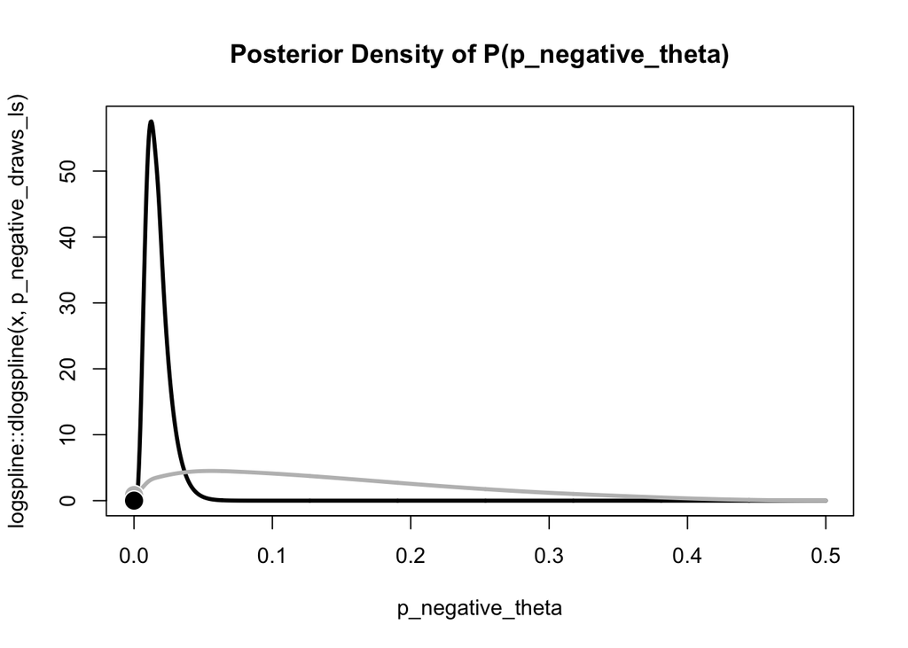

Figure 3: Posterior and prior density for the proportion of participants with a negative flash lag effect, $p(\theta_i<0)$. The Bayes factor in favor of the alternative hypothesis ($p(\theta_i<0) > 0$) over the null hypothesis ($p(\theta_i<0) = 0$) is given by the ratio of the prior density to the posterior density at $p(\theta_i<0) = 0$.

```r
# Extract posterior samples for p_negative_theta
p_negative_draws <- tidybayes::gather_draws(fle_bayes, p_negative_theta)

# logspline approximation of posterior density
p_negative_draws_ls <- logspline::logspline(
  p_negative_draws$.value
  , lbound = 0, ubound = 0.5
)

# logspline approximation of prior density
prior_ls <- rnorm(1e5, mean = fle_stan_data$pi_mean, sd = fle_stan_data$pi_sd) |>
  pnorm() |>
  (\(x) x / 2)() |>
  logspline::logspline(lbound = 0, ubound = 0.5)

prior_density <- logspline::dlogspline(0, prior_ls)
posterior_density <- logspline::dlogspline(0, p_negative_draws_ls)


curve(
  logspline::dlogspline(x, p_negative_draws_ls)
  , from = 0, to = 0.5
  , col = "black", lwd = 3
  , main = "Posterior Density of P(p_negative_theta)"
  , xlab = "p_negative_theta"
  , n = 1001
)

curve(
  logspline::dlogspline(x, prior_ls)
  , from = 0, to = 0.5
  , col = "grey", lwd = 3
  , add = TRUE
  , n = 1001
)

points(
  x = c(0, 0)
  , y = c(prior_density, posterior_density)
  , col = c("white", "white")
  , bg = c("grey", "black")
  , pch = 21
  , cex = 2
)
```

```r
bayes_factor_10 <- prior_density / posterior_density
bayes_factor_10
```

```
[1] 331.9405
```

We still find overwhelming evidence for the unconstrained population distribution. In other words, the assumption that noone exhibits a flash lead effect, seems highly implausible.

## Stochastic Dominance Analysis

**Positive effect model (dominance model)**: Order constraint, constrains individual effects to be positive, but effects differ/vary interindividually. Truncated normal distribution as suggested by literature.

Defining $\sigma_{\theta}$ the same way as in the unconstrained model would not make any sense conceptually, since in this model $p(\theta_i<0)$ is assumed to be zero. Therefore chose log-normal as informative prior (as prior of unconstrained model was similar to prior for $\mu_\theta$).

**Common-effect model**: No individual variablity in effects, all inidividual share a common, constant effect different from zero (positive). Unlikely to be an accurate representation of effects in psychology, but used as (1) benchmark to check for individual differences (model could be preferred should individual difference be very small) and (2) design check (design might not be able to capture individual differences).

Priors are only needed for $\theta$ (as there is uncertainty regarding the size of the common effect) and $\sigma_\epsilon^2$. Logarithmic normal distribution as prior for $\theta$, constraining it to positive real numbers (paralleling prior of $\mu_{\theta}$ in unconstrained model).

**Average null model**: Average effect across individuals is constrained to be zero, but effects are assumed to vary across individuals. Conceptualized as a more forgiving alternative to the null model (see below), less reactive to contaminated data. $\theta_i$ are modeled as normally distributed around a mean of zero. Only slight deviations from zero align with the idea of this model as an alternative to the null model, therefore steep log-normal distribution with relatively small mean to be chosen as prior for $\sigma_{\theta}$ (see average null vs unconstrained).

**Null model**: Specifies a true effect of zero for all individuals, most constrained model. Used as benchmark for no effect and no interindividual variability. There is no uncertainty regarding the size of the effect, as it is assumed to be zero. So no prior for theta. Only prior for sigma (measurement error around true $\theta = 0$) needed.

## (1) Dominance (truncated normal) vs unconstrained

Priors chosen to be similar to priors of unconstrained model, therefore approximately same percentage of theoretically negative $\theta_i$. But this time, negative $\theta_i$ are excluded / impossible by stan model definition (truncated normal distribution).

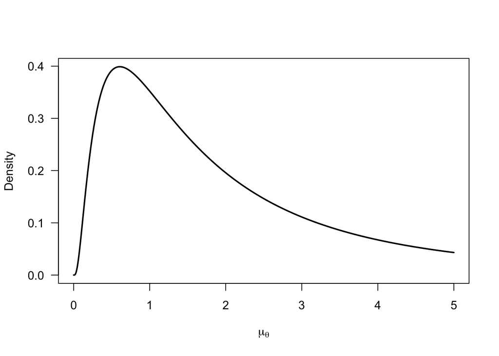

Prior distribution of $\mu_{\theta}$ in dominance model

```r
mu_prior_truncn <- rlnorm(1e5, meanlog = 0.5, sdlog = 1)

curve(
  dlnorm(x, meanlog = 0.5, sdlog = 1)
  , from = 0, to = 5
  , lwd = 2
  , xlab = expression(mu[theta])
  , ylab = "Density"
  , las = 1
  , n = 1001
)
```

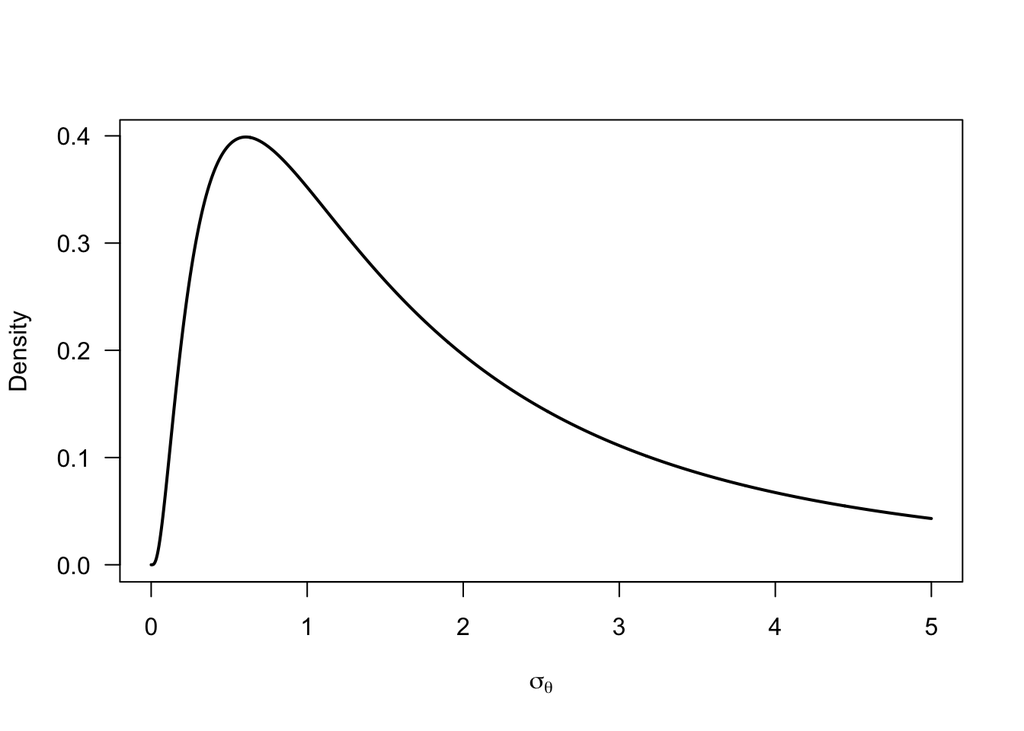

Prior distribution of $\sigma_{\theta}$ in dominance model

```r
sigma_prior_truncn <- rlnorm(1e5, meanlog = 0.5, sdlog = 1)

curve(
  dlnorm(x, meanlog = 0.5, sdlog = 1)
  , from = 0, to = 5
  , lwd = 2
  , xlab = expression(sigma[theta])
  , ylab = "Density"
  , las = 1
  , n = 1001
)
```

```r
pse_dominance_model <- readLines("../PartA/models/pse-dominance.stan") |>
  paste(collapse = "\n")

fle_stan_dominance_data <- list(
  N = nrow(FLE_data) |> as.integer()
  , n_subjects = length(unique(FLE_data$ID)) |> as.integer()
  , id = as.integer(as.factor(FLE_data$ID))
  , y = FLE_data$FLE_dva

  # Prior settings
  , mu_theta_mean = 0.5
  , mu_theta_sd = 1
  , sigma_theta_mean = 0.5
  , sigma_theta_sd = 1
)

fle_dominance_bayes <- rstan::stan(
  model_code = pse_dominance_model
  , data = fle_stan_dominance_data
  , iter = 1e5/4 + 1000
  , warmup = 1000
  , chains = 4
  , cores = 4
  , seed = 123
)
```

```
Trying to compile a simple C file
```

[output not shown]

```r
# model diagnostics
str_post_dominance<- data.frame(summary(fle_dominance_bayes)$summary)
check_hmc_diagnostics(fle_dominance_bayes)
```

```
Divergences:
```

```
0 of 100000 iterations ended with a divergence.
```

```
Tree depth:
```

```
0 of 100000 iterations saturated the maximum tree depth of 10.
```

```
Energy:
```

```
E-BFMI indicated no pathological behavior.
```

### Estimates of individual effects

```r
theta_i_truncn <- tidybayes::gather_draws(
  fle_dominance_bayes
  , theta[i]
)

theta_i_trunc_ordered <- tidybayes::median_qi(theta_i_truncn) |>
  mutate(i = factor(i
                    ,levels = unique(i)[order(.value)]        #levels are ordered after median, 64 = min value = first level
                    ,labels = unique(i)[order(.value)]        #I create this solely for creating levels in draws, as geom-f calls on draws
                    )
         )

# Plot median estimates
truncated_caterpillar <- theta_i_truncn |>
  mutate(ID = factor(i
                     ,levels = unique(theta_i_trunc_ordered$i)[order(theta_i_trunc_ordered$.value)]  #new var ID with ordered med levels
                     ,labels = unique(theta_i_trunc_ordered$i)[order(theta_i_trunc_ordered$.value)]
                     )
  ) |>
  rename(theta = .value) |>
  ggplot() +
  aes(x = ID, y = theta) +
  geom_hline(yintercept = 0, color = "black", linetype = "22") + #string-linetype: line for 2 units, followed by 2 off
  stat_pointinterval(           #draws point est + CI for draw-input, point_interval function is median_qi by default
    fill = viridisLite::inferno(1, begin = 0.9), interval_color = viridisLite::inferno(1, begin = 0.9), point_color = "white"
    , .width = c(.95), fatten_point = 2, linewidth = 1, shape = 21
  ) +
  labs(y = expression(theta[i]), x = "Participant ID") +
  coord_cartesian(ylim = c(0,6)) +
  papaja::theme_apa(base_size = 16) +
  theme(
    axis.text.x = element_text(size = 8, angle = 90, vjust = 0.5, hjust = 0)
  )
```

```r
post_populDist_truncated <- tidybayes::gather_draws(
  fle_dominance_bayes
  , mu_theta, sigma_theta
) |>
  tidyr::nest(data = c(.chain, .iteration, .draw)) |>
  tidyr::pivot_wider(names_from = .variable, values_from = .value) |>
  mutate(
    density = purrr::map2(                      # iteration of each density function for each pair of mu and sigma
      mu_theta, sigma_theta,
      \(mu, sigma){
        dnorm(
          x = seq(0, 6, length.out = 101)
          , mean = mu
          , sd = sigma
        )
      }
    )
    ,theta = list(seq(0, 6, length.out = 101))    # corresponsing values on x for plot
  )

 theta_trunc_dist <- post_populDist_truncated |>
  tidyr::unnest(cols = c(density, theta)) |>
  ggplot() +
  aes(x = theta, y = density) +
   geom_vline(xintercept = 0, color = "black", linetype = "22") +
   geom_hline(yintercept = 0, color = "black") +
   geom_lineribbon(                              # function designed to use with output from point_interval
     aes(ymin = after_stat(ymin), ymax = after_stat(ymax))
     , stat = "summary"
     , fun.data = "median_qi"
     , color = "black"
     , fill = "black"
     , alpha = 0.2
   ) +
   labs(x = expression(theta[i]), y = "Density") +
   papaja::theme_apa(base_size = 16)
```

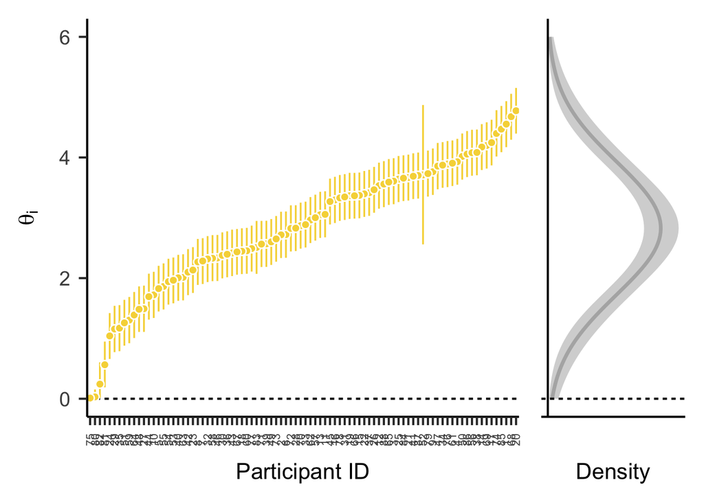

Figure 4: Posterior distribution of individual effects $\theta_i$ for each participant (left) and the posterior distribution of the population distribution of individual effects $\theta_i$ (right). The horizontal dashed line marks the point of no effect, i.e., $\theta_i = 0$.

```r
truncated_caterpillar + (theta_trunc_dist + coord_flip() + theme(axis.ticks.x = element_blank(), axis.text.x = element_blank())) +
  plot_layout(ncol = 2, width = c(1, 1/3), axes = "collect_y")
```

### Bayes factor with unconstrained model

```r
unconstrained_ml <- bridge_sampler(fle_bayes, method = "warp3", repetitions = 30, silent = TRUE)
dominance_ml <- bridge_sampler(fle_dominance_bayes, method = "warp3", repetitions = 30, silent = TRUE)

# bayes factor
bayes_factor(unconstrained_ml, dominance_ml)
```

```
Estimated Bayes factor (based on medians of log marginal likelihood estimates)
 in favor of x1 over x2: 176713231424921152837734431020854280192.00000
Range of estimates: 175969109970533549586876210015507578880.00000 to 177432016977888481026165567406540324864.00000
Interquartile range: 499779068984500803955139308209307648.00000
```

## (2) Common vs unconstrained

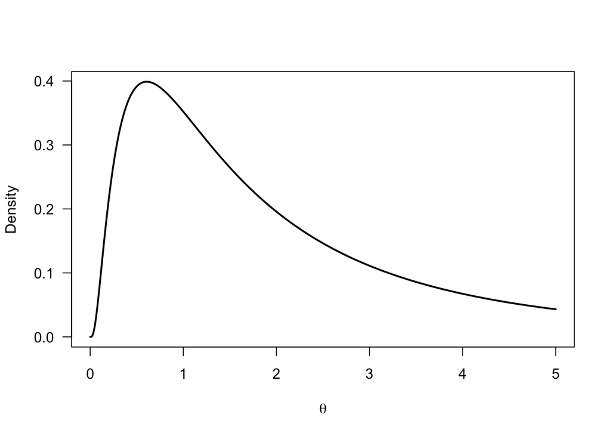

Prior distribution of $\theta$ in common model

```r
mu_prior_common <- rlnorm(1e5, meanlog = 0.5, sdlog = 1)

curve(
  dlnorm(x, meanlog = 0.5, sdlog = 1)
  , from = 0, to = 5
  , lwd = 2
  , xlab = expression(theta)
  , ylab = "Density"
  , las = 1
  , n = 1001
)
```

```r
pse_common_model <- readLines("../PartA/models/pse-common.stan") |>
  paste(collapse = "\n")

fle_stan_common_data <- list(
  N = nrow(FLE_data) |> as.integer()
  , n_subjects = length(unique(FLE_data$ID)) |> as.integer()
  , id = as.integer(as.factor(FLE_data$ID))
  , y = FLE_data$FLE_dva

  # Prior settings
  , theta_mean = 0.5
  , theta_sd = 1
)

fle_common_bayes <- rstan::stan(
  model_code = pse_common_model
  , data = fle_stan_common_data
  , iter = 1e5/4 + 1000
  , warmup = 1000
  , chains = 4
  , cores = 4
  , seed = 123
)
```

```
Trying to compile a simple C file
```

[output not shown]

```r
# model diagnostics
str_post_common <- data.frame(summary(fle_common_bayes)$summary)
check_hmc_diagnostics(fle_common_bayes)
```

```
Divergences:
```

```
0 of 100000 iterations ended with a divergence.
```

```
Tree depth:
```

```
0 of 100000 iterations saturated the maximum tree depth of 10.
```

```
Energy:
```

```
E-BFMI indicated no pathological behavior.
```

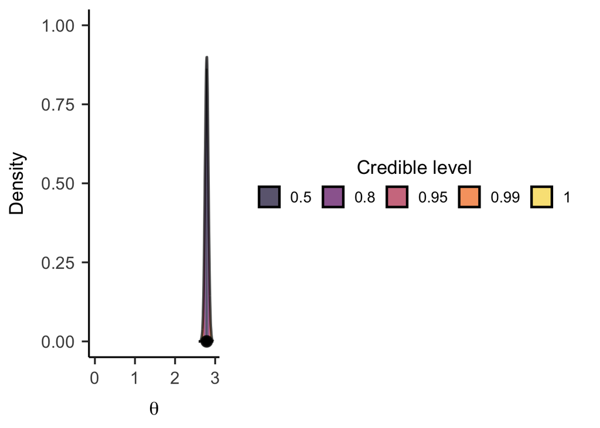

Figure 5: Posterior distributions for the common effect $\theta$.

```r
tidybayes::gather_draws(
  fle_common_bayes
  , theta
) |>
  ggplot() +
  aes(x = .value, fill = after_stat(level)) +
  stat_halfeye(fill_type = "segments", normalize = "panels", .width = c(.5, .8, .95, .99, 1), slab_color = "black", alpha = 0.7, fatten_point = 2, interval_size_range = c(1, 2)) +
  annotate("point", x = c(0, 0.5), y = 0, color = "white") +
  scale_fill_viridis_d(option = "B", begin = 0.9, end = 0.1) +
  guides(
    fill = guide_legend(
      title = "Credible level"
      , override.aes = list(color = NA)
      , reverse = TRUE
      , direction = "horizontal"
      , title.position = "top"
      , title.hjust = 0.5
    )
  ) +
  labs(x = expression(theta), y = "Density") +
  papaja::theme_apa(base_size = 16)
```

### Bayes factor with unconstrained model

```r
common_ml <- bridge_sampler(fle_common_bayes, method = "warp3", repetitions = 30, silent = TRUE)

bayes_factor(unconstrained_ml, common_ml)
```

[output not shown]

## (3) Average null vs unconstrained

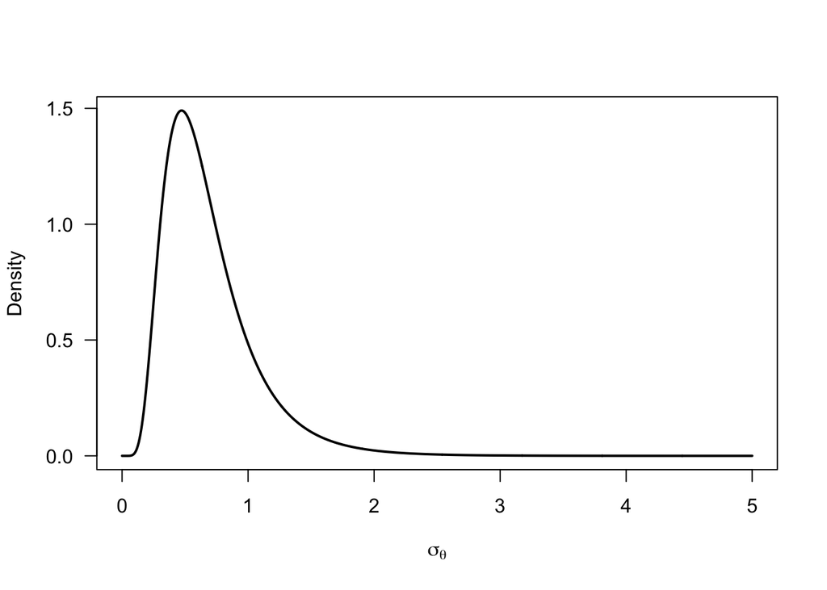

Prior distribution of $\sigma_{\theta}$ in average null model

```r
sigma_prior_average <- rlnorm(1e5, meanlog = -0.5, sdlog = 0.5)

curve(
  dlnorm(x, meanlog = -0.5, sdlog = 0.5)
  , from = 0, to = 5
  , lwd = 2
  , xlab = expression(sigma[theta])
  , ylab = "Density"
  , las = 1
  , n = 1001
)
```

```r
# Mean of prior sigma_theta
exp(-0.5 + (0.5)^2/2)
```

```
[1] 0.6872893
```

```r
pse_average_model <- readLines("../PartA/models/pse-average-null.stan") |>
  paste(collapse = "\n")

fle_stan_average_data <- list(
  N = nrow(FLE_data) |> as.integer()
  , n_subjects = length(unique(FLE_data$ID)) |> as.integer()
  , id = as.integer(as.factor(FLE_data$ID))
  , y = FLE_data$FLE_dva

  # Prior settings
  , sigma_theta_mean = -0.5
  , sigma_theta_sd = 0.5
)

fle_average_bayes <- rstan::stan(
  model_code = pse_average_model
  , data = fle_stan_average_data
  , iter = 1e5/4 + 1000
  , warmup = 1000
  , chains = 4
  , cores = 4
  , seed = 123
)
```

```
Trying to compile a simple C file
```

[output not shown]

```r
# model diagnostics
str_post_average <- data.frame(summary(fle_average_bayes)$summary)
check_hmc_diagnostics(fle_average_bayes)
```

```
Divergences:
```

```
0 of 100000 iterations ended with a divergence.
```

```
Tree depth:
```

```
0 of 100000 iterations saturated the maximum tree depth of 10.
```

```
Energy:
```

```
E-BFMI indicated no pathological behavior.
```

### Estimates of individual effects

```r
theta_i_average <- tidybayes::gather_draws(
  fle_average_bayes
  , theta[i]
)

theta_i_average_ordered <- tidybayes::median_qi(theta_i_average) |>
  mutate(i = factor(i
                    ,levels = unique(i)[order(.value)]
                    ,labels = unique(i)[order(.value)]        #I create this solely for creating levels in draws, as geom-f calls on draws
                    )
         )

# Plot median estimates
average_caterpillar <- theta_i_average |>
  mutate(ID = factor(i
                     ,levels = unique(theta_i_average_ordered$i)[order(theta_i_average_ordered$.value)]
                     ,labels = unique(theta_i_average_ordered$i)[order(theta_i_average_ordered$.value)]
                     )
  ) |>
  rename(theta = .value) |>
  ggplot() +
  aes(x = ID, y = theta) +
  geom_hline(yintercept = 0, color = "black", linetype = "22") + #string-linetype: line for 2 units, followed by 2 off
  stat_pointinterval(           #draws point est + CI for draw-input, point_interval function is median_qi by default
    aes(fill = after_stat(y) < 0, interval_color = after_stat(y) < 0),
    point_color = "white", .width = c(.95), fatten_point = 2, linewidth = 1, shape = 21
  ) +
  scale_fill_viridis_d(option = "B", begin = 0.9, end = 0.1, aesthetics = c("fill", "interval_color")) +
  guides(interval_color = "none", fill = "none", linetype = "none") +
  labs(y = expression(theta[i]), x = "Participant ID") +
  coord_cartesian(ylim = c(-4,7)) +
  papaja::theme_apa(base_size = 16) +
  theme(
    axis.text.x = element_text(size = 8, angle = 90, vjust = 0.5, hjust = 0)
  )
```

```r
post_populDist_average <- tidybayes::gather_draws(
  fle_average_bayes
  , sigma_theta
) |>
  tidyr::nest(data = c(.chain, .iteration, .draw)) |>
  tidyr::pivot_wider(names_from = .variable, values_from = .value) |>
  mutate(
    mu_theta = 0
  ) |>
  mutate(
    density = purrr::map2(                      # iteration of each density function for each pair of mu and sigma
      mu_theta, sigma_theta,
      \(mu, sigma){
        dnorm(
          x = seq(-4, 7, length.out = 101)
          , mean = mu
          , sd = sigma
        )
      }
    )
    ,theta = list(seq(-4, 7, length.out = 101))    # corresponsing values on x for plot
  )

 theta_average_dist <- post_populDist_average |>
  tidyr::unnest(cols = c(density, theta)) |>
  ggplot() +
  aes(x = theta, y = density) +
   geom_vline(xintercept = 0, color = "black", linetype = "22") +
   geom_hline(yintercept = 0, color = "black") +
   geom_lineribbon(                              # function designed to use with output from point_interval
     aes(ymin = after_stat(ymin), ymax = after_stat(ymax))
     , stat = "summary"
     , fun.data = "median_qi"
     , color = "black"
     , fill = "black"
     , alpha = 0.2
   ) +
   scale_fill_viridis_d(option = "B", begin = 0.9, end = 0.1) +
   guides(fill = "none") +
   labs(x = expression(theta[i]), y = "Density") +
   papaja::theme_apa(base_size = 16)
```

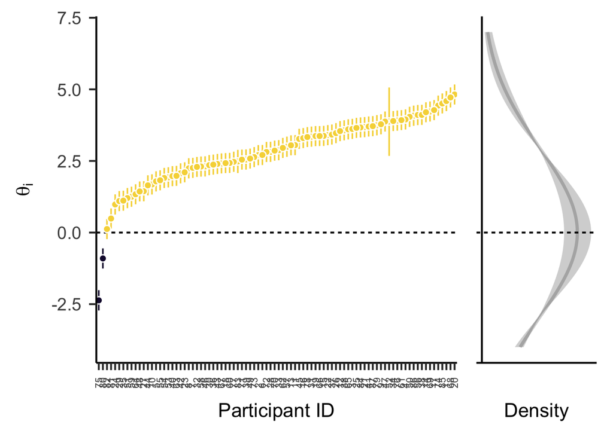

```r
average_caterpillar + (theta_average_dist + coord_flip() + theme(axis.ticks.x = element_blank(), axis.text.x = element_blank())) +
  plot_layout(ncol = 2, width = c(1, 1/3), axes = "collect_y", guides = "collect")
```

### Bayes factor with unconstrained model

```r
average_ml <- bridge_sampler(fle_average_bayes, method = "warp3", repetitions = 30, silent = TRUE)

bayes_factor(unconstrained_ml, average_ml)
```

```
Estimated Bayes factor (based on medians of log marginal likelihood estimates)
 in favor of x1 over x2: 120908011472495689044865121880375296.00000
Range of estimates: 120536651207994297744414568964161536.00000 to 121080385237422616135379582262968320.00000
Interquartile range: 155139250226718053583032904843264.00000
```

## (4) Null vs unconstrained

```r
pse_null_model <- readLines("../PartA/models/pse-null.stan") |>
  paste(collapse = "\n")

fle_stan_null_data <- list(
  N = nrow(FLE_data) |> as.integer()
  , n_subjects = length(unique(FLE_data$ID)) |> as.integer()
  , id = as.integer(as.factor(FLE_data$ID))
  , y = FLE_data$FLE_dva
)

fle_null_bayes <- rstan::stan(
  model_code = pse_null_model
  , data = fle_stan_null_data
  , iter = 1e5/4 + 1000
  , warmup = 1000
  , chains = 4
  , cores = 4
  , seed = 123
)
```

```
Trying to compile a simple C file
```

[output not shown]

```r
# model diagnostics
str_post_null <- data.frame(summary(fle_null_bayes)$summary)
check_hmc_diagnostics(fle_null_bayes)
```

```
Divergences:
```

```
0 of 100000 iterations ended with a divergence.
```

```
Tree depth:
```

```
0 of 100000 iterations saturated the maximum tree depth of 10.
```

```
Energy:
```

```
E-BFMI indicated no pathological behavior.
```

### Bayes factor with unconstrained model

```r
null_ml <- bridge_sampler(fle_null_bayes, method = "warp3", repetitions = 30, silent = TRUE)
bayes_factor(unconstrained_ml, null_ml)
```

```
Estimated Bayes factor (based on medians of log marginal likelihood estimates)
 in favor of x1 over x2:    Inf
Range of estimates:    Inf to    Inf
Interquartile range:    NaN
```

# Alternative dominance models

## Log-normal distributed $\theta_i$

In this model priors are put on the mean ($\bar{x}$) and the standard deviation ($s$) of the log-normal distribution. We chose this approach because we assume that expressing prior beliefs about the mean and standard deviation of $\theta_i$ is more intuitive than expressing prior beliefs about the parameters $\mu$ and $\sigma$ of the log-normal distribution.

```r
mean_prior_log <- rlnorm(1e5, meanlog = 0.5, sdlog = 1)
sd_prior_log <-rlnorm(1e5, meanlog = 0.5, sdlog = 1)

pse_logN_model <- readLines("../PartA/models/pse-dominance-logN.stan") |>
  paste(collapse = "\n")

fle_stan_logN_data <- list(
  N = nrow(FLE_data) |> as.integer()
  , n_subjects = length(unique(FLE_data$ID)) |> as.integer()
  , id = as.integer(as.factor(FLE_data$ID))
  , y = FLE_data$FLE_dva

  # Prior settings
  , mean_logN_mu = 0.5
  , mean_logN_sigma = 1
  , sd_logN_mu = 0.5
  , sd_logN_sigma = 1
)

fle_logN_bayes <- rstan::stan(
  model_code = pse_logN_model
  , data = fle_stan_logN_data
  , iter = 1e5/4 + 1000
  , warmup = 1000
  , chains = 4
  , cores = 4
  , seed = 123
)
```

```
Trying to compile a simple C file
```

[output not shown]

```r
# model diagnostics
str_post_logN <- data.frame(summary(fle_logN_bayes)$summary)
check_hmc_diagnostics(fle_logN_bayes)
```

```
Divergences:
```

```
0 of 100000 iterations ended with a divergence.
```

```
Tree depth:
```

```
0 of 100000 iterations saturated the maximum tree depth of 10.
```

```
Energy:
```

```
E-BFMI indicated no pathological behavior.
```

### Estimated of individual effects

```r
theta_i_logN <- tidybayes::gather_draws(
  fle_logN_bayes
  , theta[i]
)

theta_i_logN_ordered <- tidybayes::median_qi(theta_i_logN) |>
  mutate(i = factor(i
                    ,levels = unique(i)[order(.value)]
                    ,labels = unique(i)[order(.value)]        #I create this solely for creating levels in draws, as geom-f calls on draws
                    )
         )

# Plot median estimates
log_normal_caterpillar <- theta_i_logN |>
  mutate(ID = factor(i
                     ,levels = unique(theta_i_logN_ordered$i)[order(theta_i_logN_ordered$.value)]  #new var ID with ordered med levels
                     ,labels = unique(theta_i_logN_ordered$i)[order(theta_i_logN_ordered$.value)]
                     )
  ) |>
  rename(theta = .value) |>
  ggplot() +
  aes(x = ID, y = theta) +
  geom_hline(yintercept = 0, color = "black", linetype = "22") + #string-linetype: line for 2 units, followed by 2 off
  stat_pointinterval(           #draws point est + CI for draw-input, point_interval function is median_qi by default
    fill = viridisLite::inferno(1, begin = 0.9), interval_color = viridisLite::inferno(1, begin = 0.9),
    point_color = "white", .width = c(.95), fatten_point = 2, linewidth = 1, shape = 21
  ) +
  labs(y = expression(theta[i]), x = "Participant ID") +
  coord_cartesian(ylim = c(0,7)) +
  papaja::theme_apa(base_size = 16) +
  theme(
    axis.text.x = element_text(size = 8, angle = 90, vjust = 0.5, hjust = 0)
  )
```

```r
post_populDist_logN <- tidybayes::gather_draws(
  fle_logN_bayes
  , mu_theta, sigma_theta
) |>
  tidyr::nest(data = c(.chain, .iteration, .draw)) |>
  tidyr::pivot_wider(names_from = .variable, values_from = .value) |>
  mutate(
    density = purrr::map2(                      # iteration of each density function for each pair of mu and sigma
      mu_theta, sigma_theta,
      \(mu, sigma){
        dlnorm(
          x = seq(0, 7, length.out = 101)
          , meanlog = mu
          , sdlog = sigma
        )
      }
    )
    ,theta = list(seq(0, 7, length.out = 101))    # corresponsing values on x for plot
  )

 theta_logN_dist <- post_populDist_logN |>
  tidyr::unnest(cols = c(density, theta)) |>
  ggplot() +
  aes(x = theta, y = density) +
   geom_vline(xintercept = 0, color = "black", linetype = "22") +
   geom_hline(yintercept = 0, color = "black") +
   geom_lineribbon(                              # function designed to use with output from point_interval
     aes(ymin = after_stat(ymin), ymax = after_stat(ymax))
     , stat = "summary"
     , fun.data = "median_qi"
     , color = "black"
     , fill = "black"
     , alpha = 0.2
   ) +
   labs(x = expression(theta[i]), y = "Density") +
   papaja::theme_apa(base_size = 16)
```

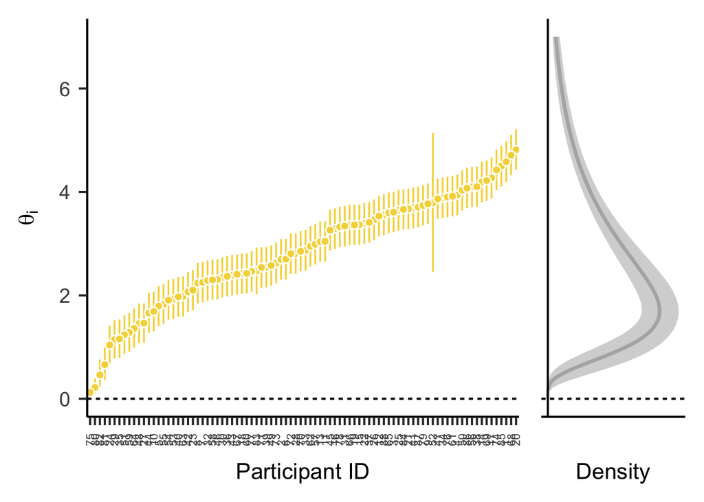

Figure 6: Posterior distribution of individual effects $\theta_i$ for each participant (left) and the posterior distribution of the population distribution of individual effects $\theta_i$ (right). The horizontal dashed line marks the point of no effect, i.e., $\theta_i = 0$.

```r
log_normal_caterpillar + (theta_logN_dist + coord_flip() + theme(axis.ticks.x = element_blank(), axis.text.x = element_blank())) +
  plot_layout(ncol = 2, width = c(1, 1/3), axes = "collect_y")
```

### Bayes factor with unconstrained model

```r
logN_ml <- bridge_sampler(fle_logN_bayes, method = "warp3", repetitions = 30, silent = TRUE)
bayes_factor(unconstrained_ml, logN_ml)
```

```
Estimated Bayes factor (based on medians of log marginal likelihood estimates)
 in favor of x1 over x2: 74334586664881568146583146738996442866457016439073144832.00000
Range of estimates: 74142751513338424828797924072591222717885771120793092096.00000 to 74501547476029369419020428674986166087611668144733552640.00000
Interquartile range: 119938133829155002593762629785538735006094590044274688.00000
```

```r
bayes_factor(logN_ml, dominance_ml) -> bf_logN_dom
```

# Prior settings

## Prior settings for mean of $\theta_i$

To assess the (possible) impact of different prior assumptions on the results of the model comparison, the prior distributions for the mean of $theta_i$ are plotted below. Since the common model assumes one fixed effect shared by all individuals, the prior on the common effect can be understood as a prior on the mean effect.

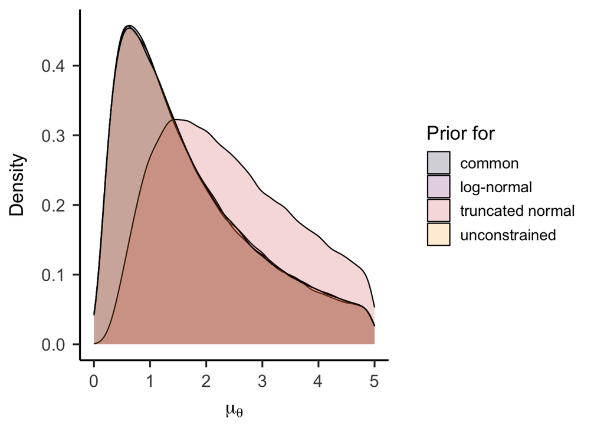

```r
# Calculate prior implied for mean of theta_i of truncated normal model
trunc_alpha <- (0-mu_prior_truncn)/sigma_prior_truncn
trunc_Z <- 1-pnorm(trunc_alpha)
mean_prior_truncn <- mu_prior_truncn + sigma_prior_truncn*(dnorm(trunc_alpha)/trunc_Z)

# Plot
data.frame(priors = c(mu_prior
                      ,mean_prior_log
                      ,mean_prior_truncn
                      ,mu_prior_common)
                      ,model = rep(c("unconstrained","log-normal","truncated normal","common"), each = 1e5)) |>
  ggplot() +
  aes(x = priors, fill = model) +
  lims(x = c(0,5)) +
  geom_density(alpha = 0.2, linewidth = 0.5) +
  labs(
    x = expression(mu[theta])
    , y = "Density"
    , fill = "Prior for"
  ) +
  scale_color_viridis_d(option = "B", begin = 0.1, end = 0.8, aesthetics = "fill") +
  papaja::theme_apa(base_size = 16)
```

## Prior settings for standard deviation of $\theta_i$

To assess the (possible) impact of different prior assumptions on the results of the model comparison, the prior distributions for the standard deviation of $theta_i$ are plotted below.

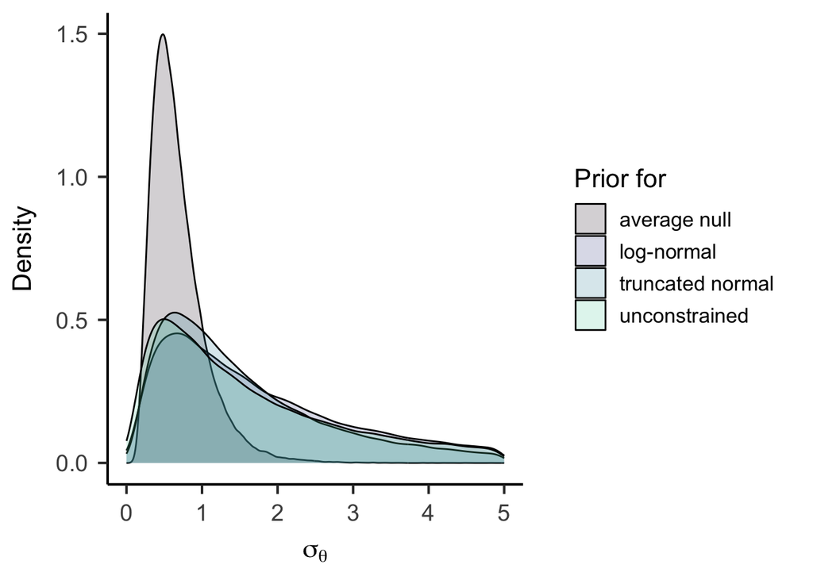

```r
# Calculate implied prior for sd of theta_i of truncated normal model
sd_prior_truncn <- sqrt(
  (sigma_prior_truncn^2)*
    (1 + trunc_alpha*dnorm(trunc_alpha)/trunc_Z -(dnorm(trunc_alpha)/trunc_Z)^2)
)

# Plot
data.frame(priors = c(sigma_prior
                      ,sd_prior_log
                      ,sd_prior_truncn
                      ,sigma_prior_average)
                      ,model = rep(c("unconstrained","log-normal","truncated normal","average null"), each = 1e5)) |>
  ggplot() +
  aes(x = priors, fill = model) +
  lims(x = c(0,5)) +
  geom_density(alpha = 0.2, linewidth = 0.5) +
  labs(
    x = expression(sigma[theta])
    , y = "Density"
    , fill = "Prior for"
  ) +
  scale_color_viridis_d(option = "G", begin = 0.1, end = 0.8, aesthetics = "fill") +
  papaja::theme_apa(base_size = 16)
```

# Bayesian model comparison

## Bayes factor summary table

```r
bfs_base_unc <- c(bayes_factor(null_ml, unconstrained_ml)$bf_median_based
    , bayes_factor(average_ml, unconstrained_ml)$bf_median_based
    , bayes_factor(common_ml, unconstrained_ml)$bf_median_based
    , bayes_factor(logN_ml, unconstrained_ml)$bf_median_based
    , bayes_factor(dominance_ml, unconstrained_ml)$bf_median_based
    , 1
    )

# Naive posterior probability: naive assumption that prior odds = 1 for all model comparisons
# -> post prob = bf / sum(bf)

npp_base_unc <- bfs_base_unc / sum(bfs_base_unc)

# model diagnostics
rhat <- c(max(str_post_null$Rhat)
          ,max(str_post_average$Rhat)
          ,max(str_post_common$Rhat)
          ,max(str_post_logN$Rhat)
          ,max(str_post_dominance$Rhat)
          ,max(str_post_unconstrained$Rhat))


# bridge sampling CV
 bridge.cv <- c(sd(null_ml$logml)/abs(mean(null_ml$logml))
                ,sd(average_ml$logml)/abs(mean(average_ml$logml))
                ,sd(common_ml$logml)/abs(mean(common_ml$logml))
                ,sd(logN_ml$logml)/abs(mean(logN_ml$logml))
                ,sd(dominance_ml$logml)/abs(mean(dominance_ml$logml))
                ,sd(unconstrained_ml$logml)/abs(mean(unconstrained_ml$logml)))

# i was getting error for `printnum()` function, so asked chatgpt to define a function

printnum <- function(
    x,
    format = "f",
    digits = 3,
    gt1 = TRUE
) {

  formatted <- formatC(
    x,
    format = format,
    digits = digits
  )

  # Optional formatting for values greater than 1
  if (!gt1) {
    formatted[x > 1] <- formatC(
      x[x > 1],
      format = format,
      digits = digits
    )
  }

  formatted
}

# summary table
data.frame(
  model = c("Null model", "Average null model", "Common model", "Log-normal model", "Truncated normal model", "Unconstrained model")
  , bf = printnum(bfs_base_unc, format = "e")
  , npp = printnum(npp_base_unc, gt1 = F, digits = 2)
  , rhat = printnum(rhat, digits = 3)
  , cv = printnum(bridge.cv, format = "e")
)  |> knitr::kable(
  col.names = c("Model ($i$)", "$BF_{i/unconstrained}$", "NPP", "max.$\\hat{R}$", "Bridge Sampling CV")
)
```

Summary table: Bayes Factors over unconstrained model (=reference model) and naive posterior probability (NPP), based on assumption of equal prior model odds. Maximum $\hat{R}$ and coefficient of variation (CV) for the bridge sampling are also given for each model.

| Model ($i$) | $BF_{i/unconstrained}$ | NPP | max.$\hat{R}$ | Bridge Sampling CV |
| --- | --- | --- | --- | --- |
| Null model | 0.000e+00 | 0.00 | 1.000 | 6.145e-09 |
| Average null model | 8.271e-36 | 0.00 | 1.000 | 7.040e-07 |
| Common model | 3.762e-285 | 0.00 | 1.000 | 1.735e-08 |
| Log-normal model | 1.345e-56 | 0.00 | 1.000 | 7.416e-07 |
| Truncated normal model | 5.659e-39 | 0.00 | 1.000 | 1.721e-06 |
| Unconstrained model | 1.000e+00 | 1.00 | 1.000 | 6.257e-07 |

# Summary

```r
bf_dom_null <- c(bayes_factor(logN_ml,null_ml)$bf_median_based
                 ,bayes_factor(dominance_ml, null_ml)$bf_median_based)
bf_unc_null <- bayes_factor(unconstrained_ml, null_ml)$bf_median_based

av_bf_dom_unc <- length(bf_dom_null)^(-1)*(sum(bf_dom_null)) / bf_unc_null
```